# Explore covariates

Histograms at 3500 meters:

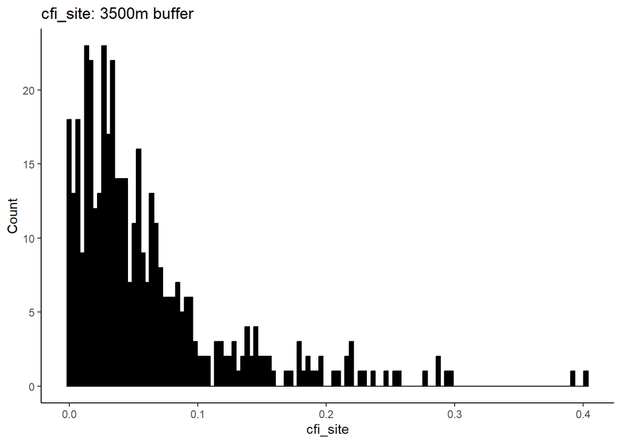

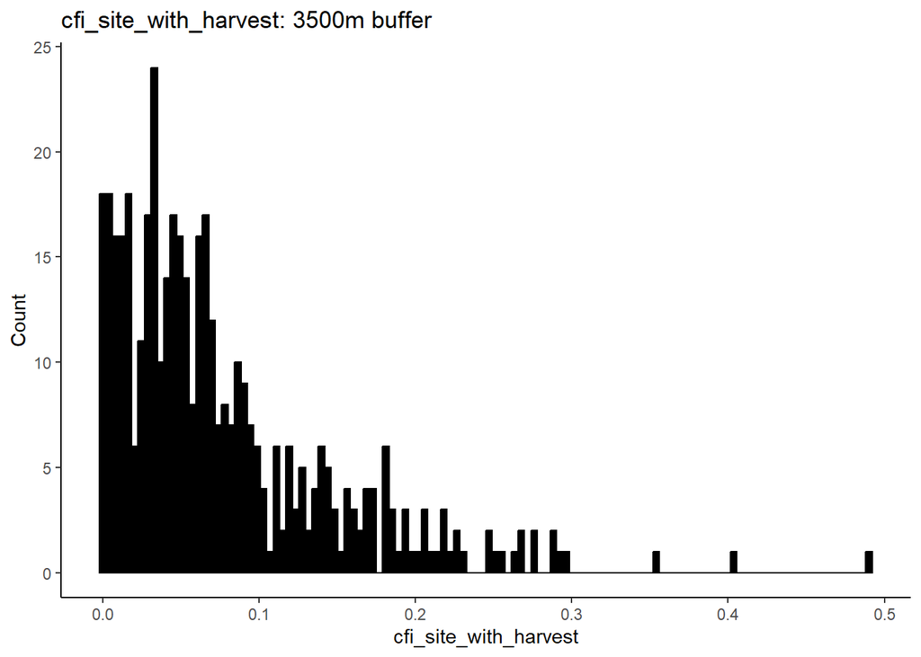

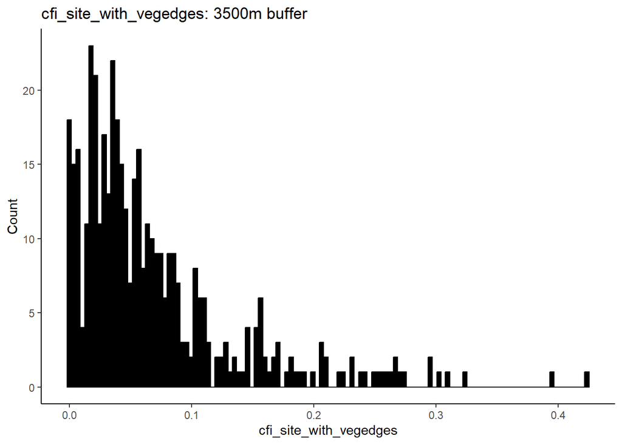

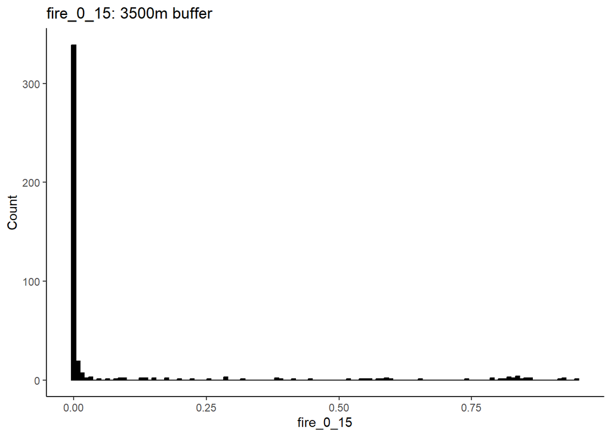

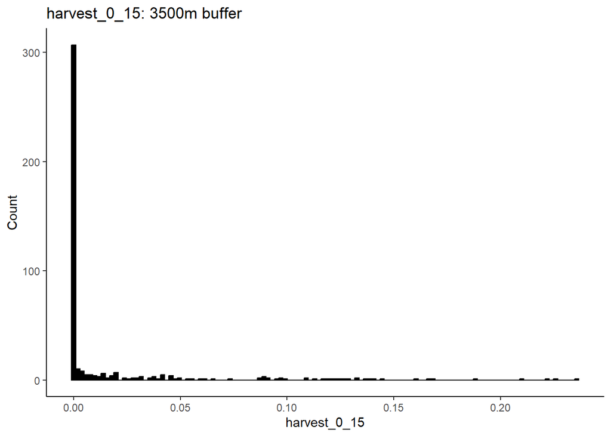

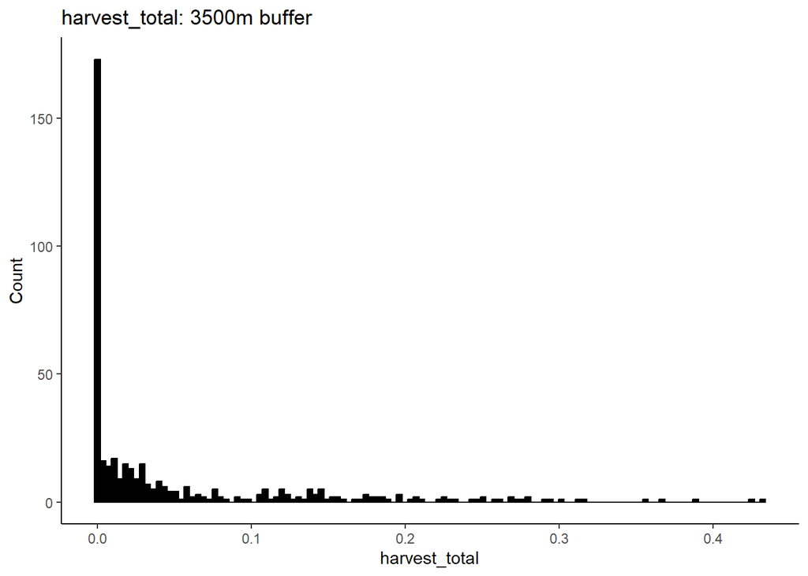

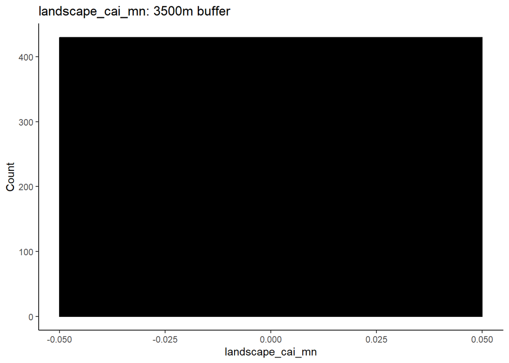

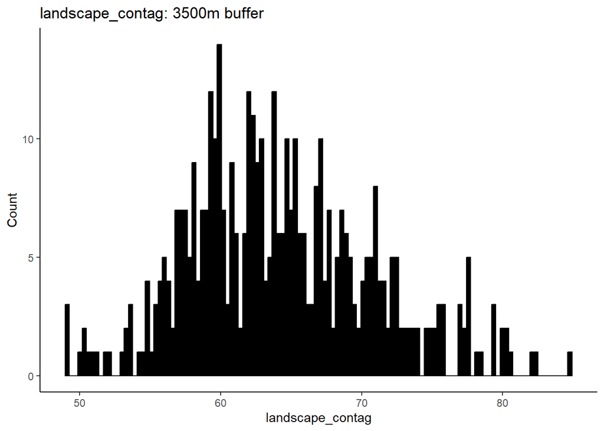

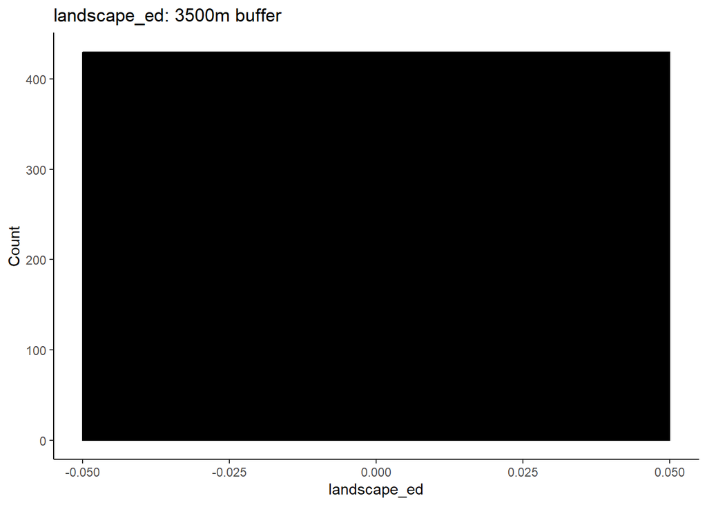

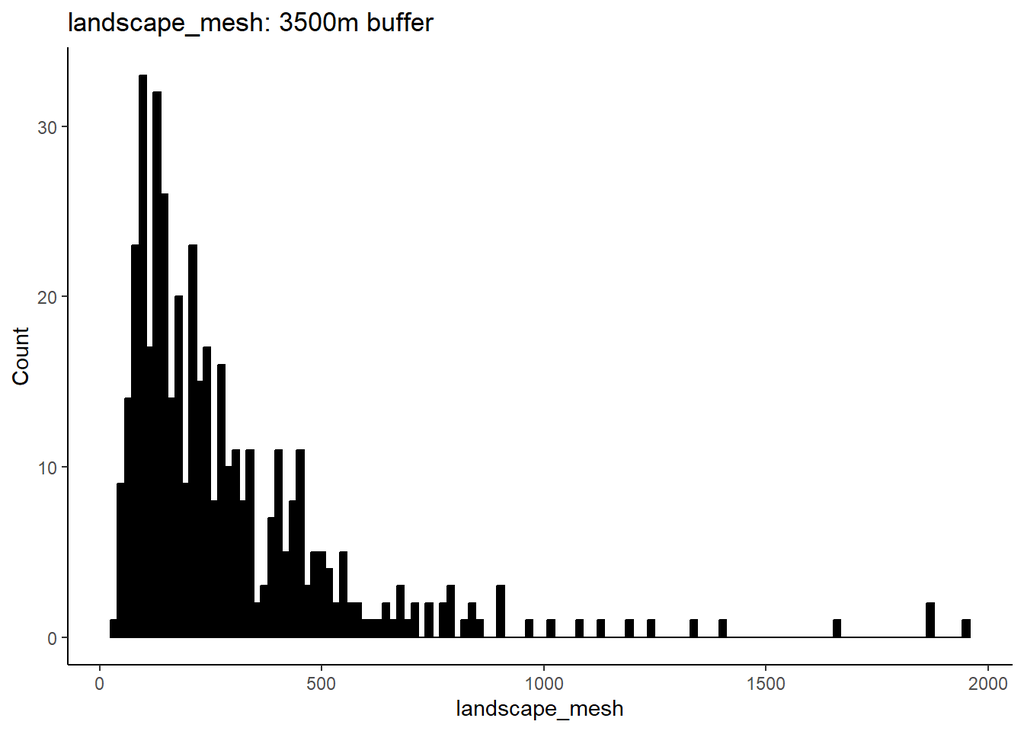

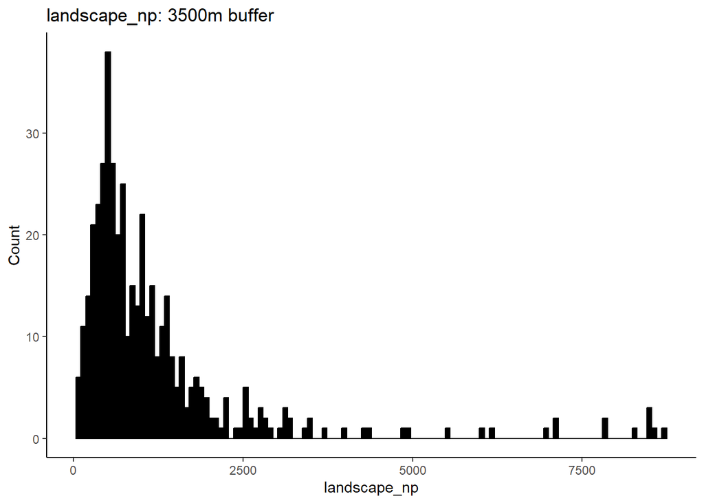

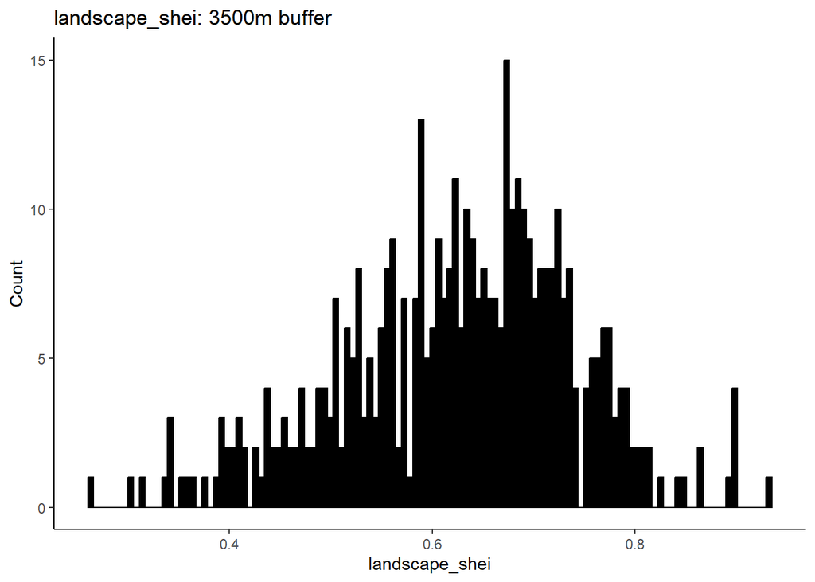

[24 more figures not shown]

```r
covs_to_explore %>%

  filter(buffer_dist == 3500) %>%

  select(-(1:8)) %>%

  # use imap which will retain both the data (x) and the variable names (y)
  imap(~ ggplot(mapping = aes(x = .x)) +
         geom_histogram(bins = 120, fill = "black", color = "black") +
         labs(title = paste0(.y, ": 3500m buffer"), x = .y, y = "Count") +
         theme_classic())
```

Box and whiskers at 3500 meters:

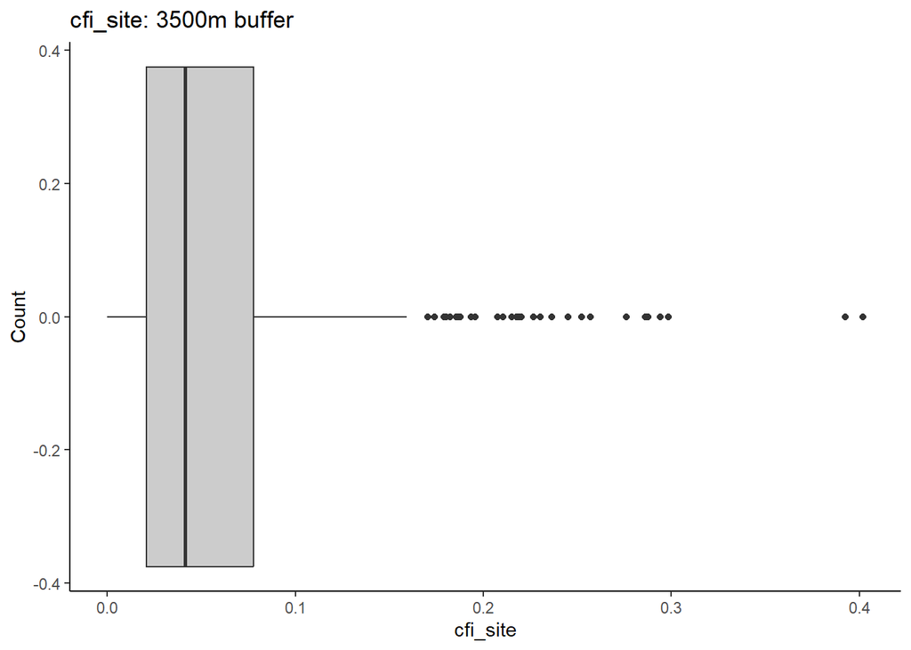

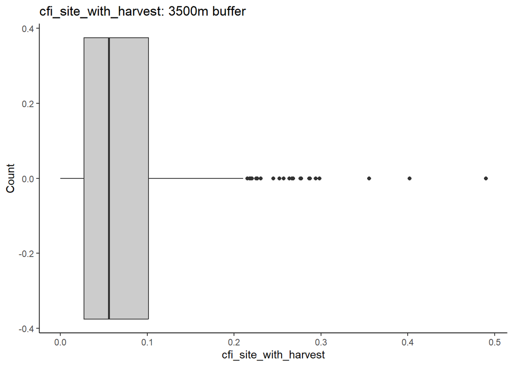

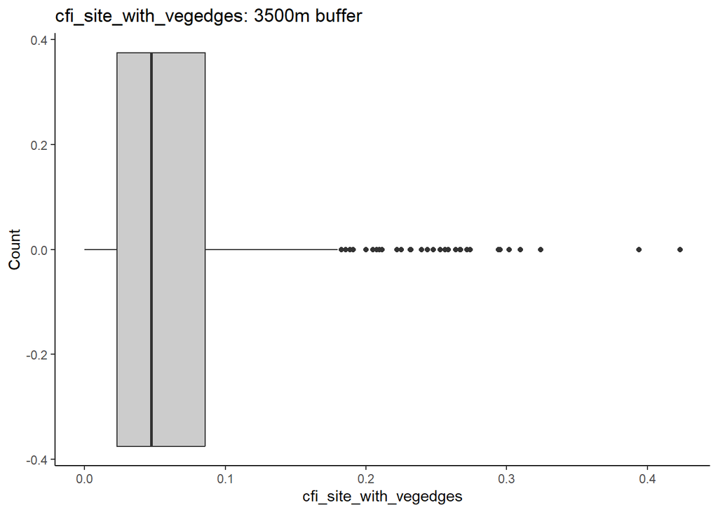

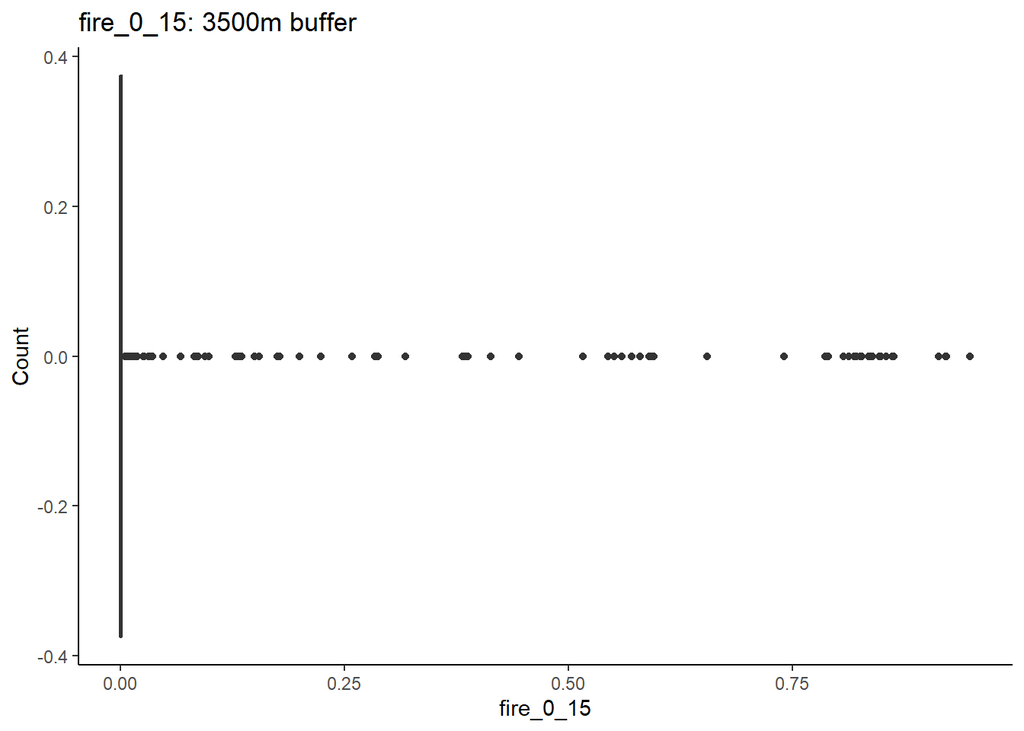

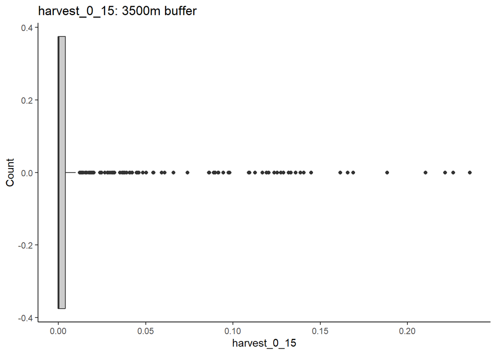

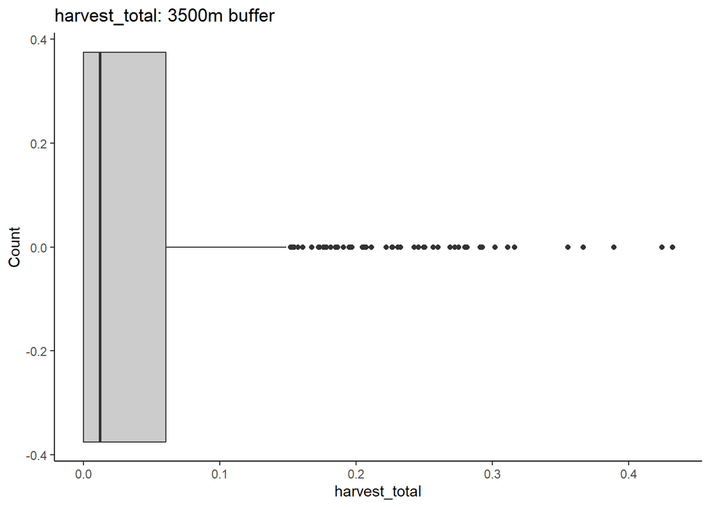

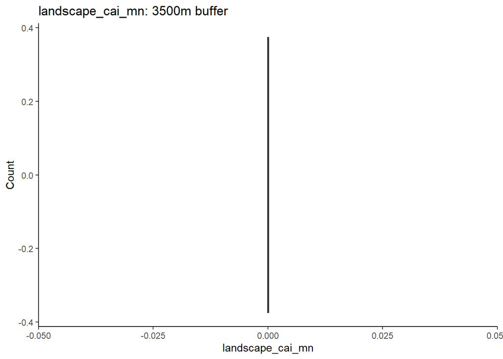

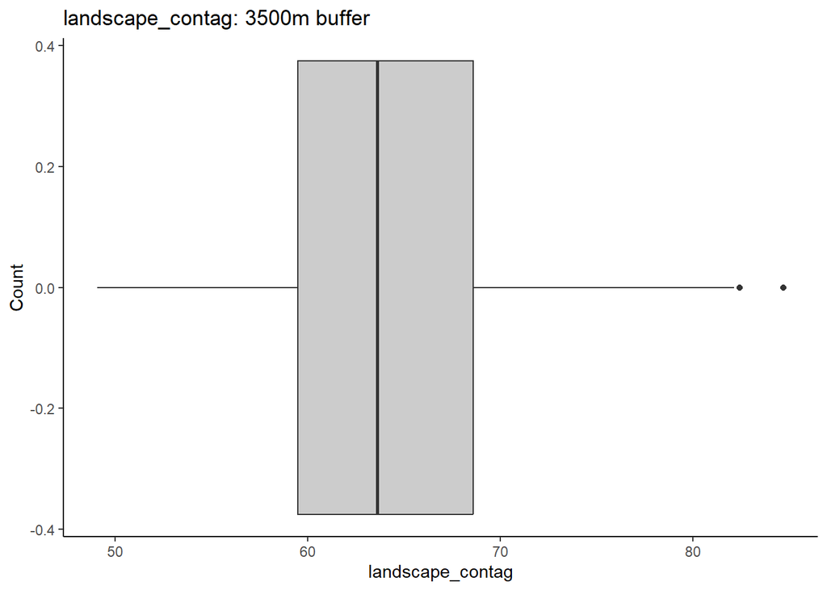

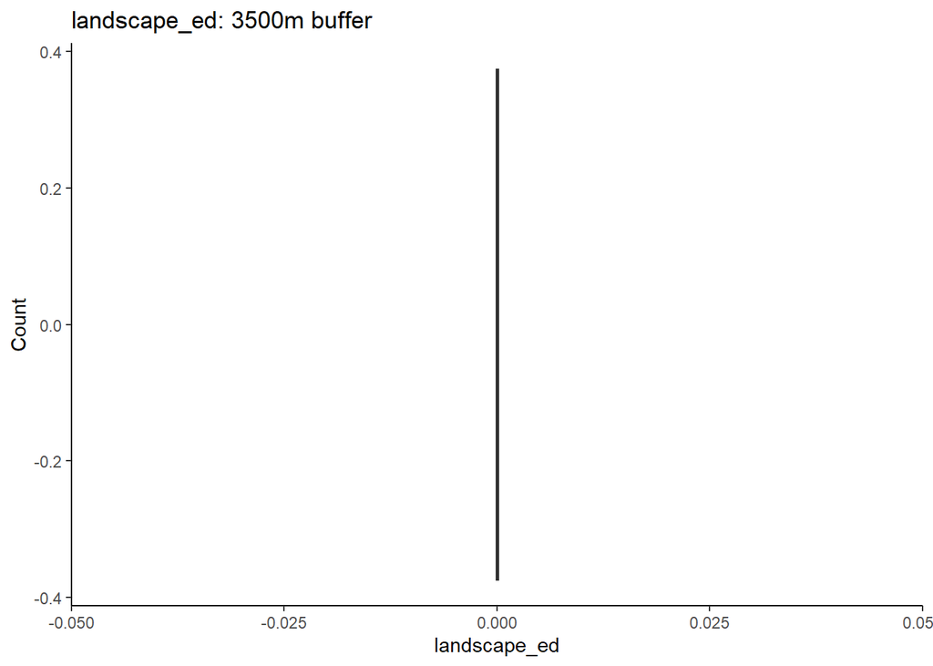

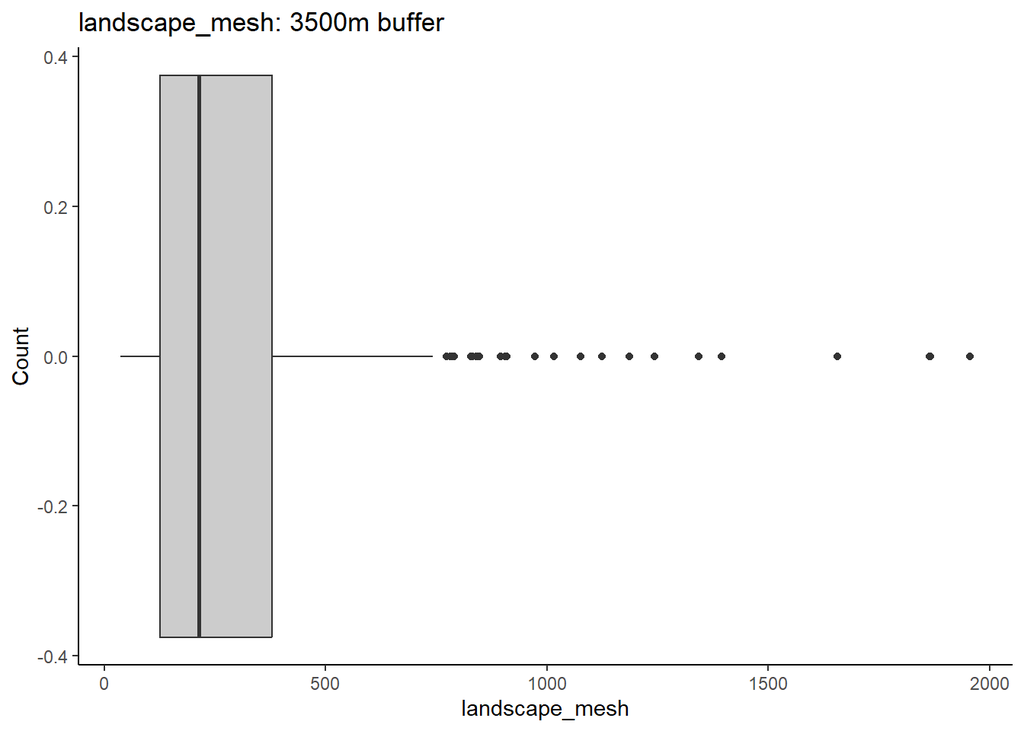

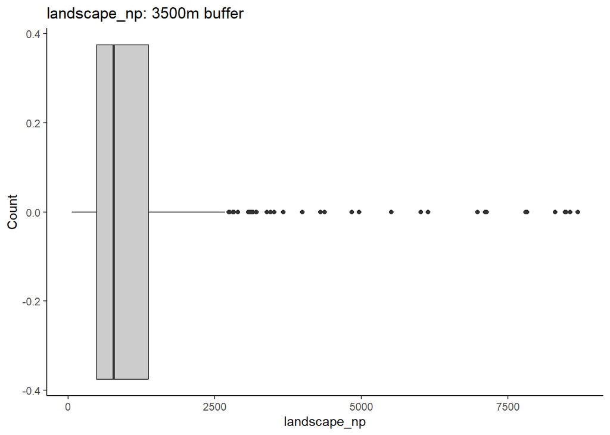

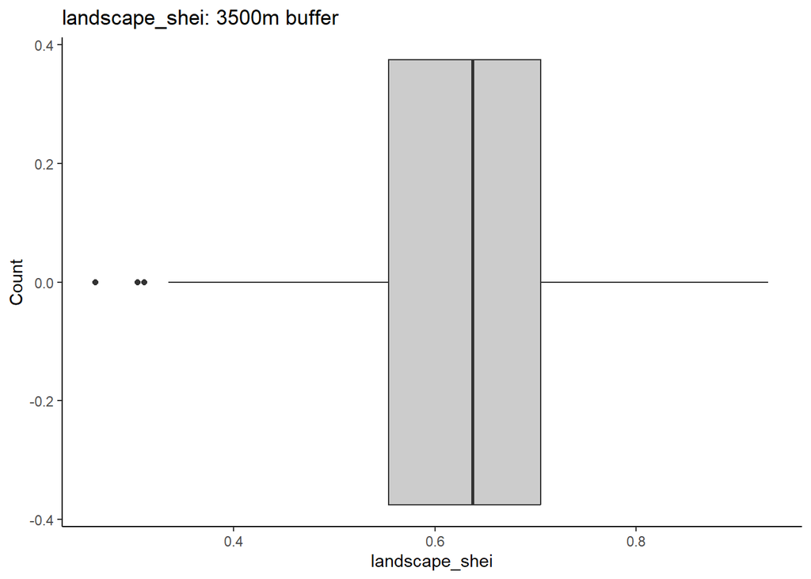

[24 more figures not shown]

```r
covs_to_explore %>%

  filter(buffer_dist == 3500) %>%

  select(-(1:8)) %>%

  # use imap which will retain both the data (x) and the variable names (y)
  imap(~ ggplot(mapping = aes(x = .x)) +
         geom_boxplot(fill = "grey80", color = "grey20") +
         labs(title = paste0(.y, ": 3500m buffer"), x = .y, y = "Count") +
         theme_classic())
```

# 3. Correlation

Now let’s look at correlation among variables. We have a ton of variables to look at so for now we’ll export to excel.

```r
# Histograms for each buffer size
corr_data <- purrr::map(unique(covs_to_explore$buffer_dist),
                        ~ covs_to_explore %>%

                          filter(buffer_dist == .x) %>%

                          # REmove the response/site columns
                          select(9:ncol(.)) %>%

                          # pairwise complete observations right now since
                          # I'm not sure how to manage all the NAs in the configuration metrics yet
                          corrr::correlate(., use = "pairwise.complete.obs",
                                           method = "spearman",
                                           diagonal = NA,
                                           quiet = TRUE) %>%

                          as_tibble() %>%

                          # REmove the bottom triangle to keep things tidy
                          mutate(across(everything(), ~ if_else(row_number() >= min(which(is.na(.))), NA, .))) %>%

                          # Get the triangle shaped properly
                          select(rev(names(.))) %>%

                          # Term at the beginning
                          relocate(term)

                        ) %>%

  # Set the names of each list element to the buffer they represent
  set_names(paste0(unique(covs_to_explore$buffer_dist), "m"))

# Nifty function here will export each list element as a separate tab in Excel :)
writexl::write_xlsx(corr_data, "./data/processed/OSM_all_covariates_correlation.xlsx")
```

Let’s also just look at the configuration metrics in a more compact format

```r
# Histograms for each buffer size
corr_data_config <- purrr::map(unique(covs_to_explore$buffer_dist),
                        ~ covs_to_explore %>%

                          filter(buffer_dist == .x) %>%

                          select(contains("landscape") | contains("nonanthro")) %>%

                          # pairwise complete observations right now since I'm not sure how to manage all the NAs in the configuration metrics yet
                          corrr::correlate(., use = "pairwise.complete.obs",
                                           method = "spearman",
                                           diagonal = NA,
                                           quiet = TRUE) %>%

                          # Same tidy and reformatting as above
                          as_tibble() %>%

                          mutate(across(everything(), ~ if_else(row_number() >= min(which(is.na(.))), NA, .))) %>%

                          select(rev(names(.))) %>%

                          relocate(term)

                        ) %>%

  # set names to buffer distance
  set_names(paste0(unique(covs_to_explore$buffer_dist), "m"))

# Export to excel
writexl::write_xlsx(corr_data_config, "./data/processed/OSM_all_config_covariates_correlation.xlsx")
```

# 4. Summary table of covariates

This will need to be tweaked at the end of the process to include all variables **at the appropriate spatial scales corresponding to the top results from the dredge**.

```r
# This is the formatted table for the paper with max/min values, etc.
covariate_table <- covs_to_explore %>%

  # Response vars removed
  select(9:ncol(.)) %>%

  # Replace NAs with zeros.
  # This should be redundant code at this point and could probably be deleted
  mutate(across(everything(), ~ replace_na(.x, 0))) %>%

  # z used as a unique delimiter `z` to separate during pivot wider.... hacky but it works
  summarise(
    across(everything(), list(
      zmean = ~mean(.),
      zmin = ~min(.),
      zmax = ~max(.),
      zmedian = ~median(.),
      zq20 = ~quantile(., probs = 0.05),
      zq80 = ~quantile(., probs = 0.95)
    ))
  ) %>%

  pivot_longer(cols = everything(), names_to = c("Covariate", ".value"), names_sep = "_z") %>%

  # Paste into one string (as in the table) so we don't have to do it in Excel
  mutate(`Median (5%, 95% quantiles)` = paste0(round(median, 2),
                                      " (", round(q20, 2),
                                      "–",
                                      round(q80, 2), ")"),
         # ...and again
         `Mean (min, max)` = paste0(round(mean, 2),
                                    " (", round(min, 2),
                                    "–",
                                    round(max, 2), ")"),
         ) %>%

  # Remove trails if it exists
  filter(Covariate != 'trails') %>%

  # REmove unformatted columns
  select(-mean, -min, -max, -median, -q20, -q80) %>%

  # Blank description column we can export later
  mutate(Description = "") %>%

  # Replace the covariate names with these pretty ones that we stored in a table
  left_join(read_csv("./tables/OSM_all_covariates_formatted_names.csv"),
            by = "Covariate") %>%

    # Swap out the names
    mutate(UglyName = Covariate,
         Covariate = PrettyName, .keep = "unused")

# End the table
writexl::write_xlsx(covariate_table, "./tables/OSM_all_covariates_summary.xlsx")
```

End script.